## The Birthrates Data Re-visited

### This dataset lists the number of live births per 10,000 23-year-old women in the United States between 1917 and 2003.

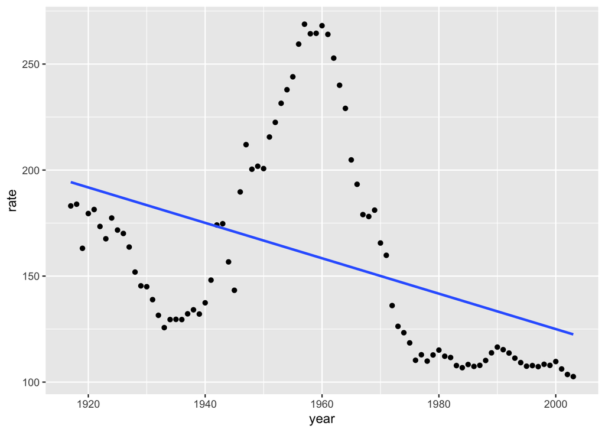

```r
library(ggplot2)
library(splines)
source("birthrates.txt");
birthrates = as.data.frame(birthrates)
names(birthrates) = c("year", "rate")
ggplot(birthrates, aes(x=year, y=rate)) +
  geom_point() + geom_smooth(method="lm", se=FALSE)
```

### Understand how R counts the df.

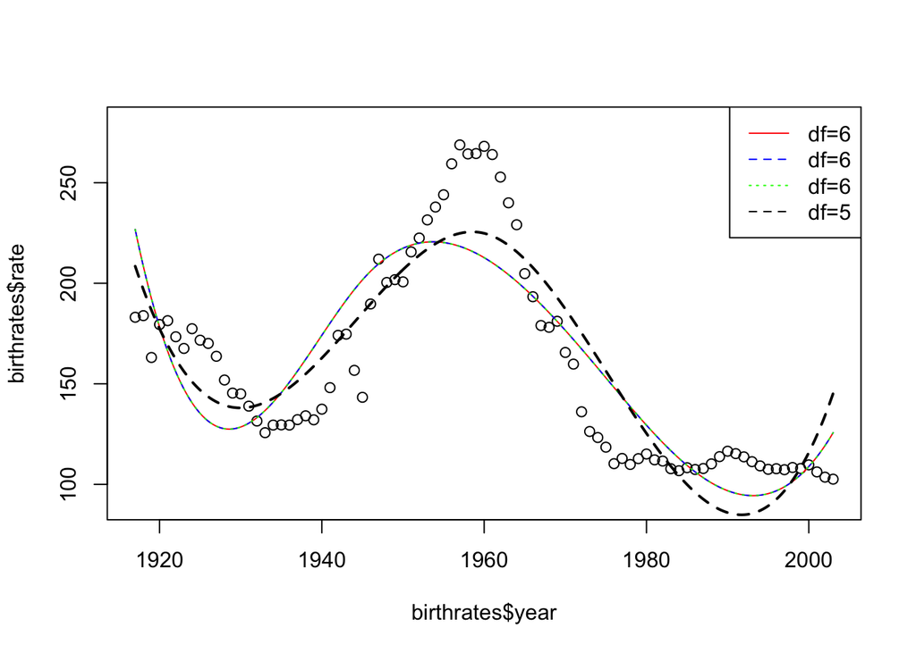

```r
fit1=lm(rate~bs(year, knots=quantile(year, c(1/3, 2/3))), data=birthrates);
fit2=lm(rate~bs(year, df=5), data=birthrates);
fit3=lm(rate~bs(year, df=6, intercept=TRUE), data=birthrates)
fit4=lm(rate~bs(year, df=5, intercept=TRUE), data=birthrates)

plot(birthrates$year, birthrates$rate, ylim=c(90,280))
lines(spline(birthrates$year, predict(fit1)), col="red", lty=1)
lines(spline(birthrates$year, predict(fit2)), col="blue", lty=2)
lines(spline(birthrates$year, predict(fit3)), col="green", lty=3)
lines(spline(birthrates$year, predict(fit4)), lty=2, lwd=2)
legend("topright", lty=c(1,2,3,2), col=c("red", "blue", "green","black"), legend=c("df=6", "df=6", "df=6","df=5"))
```

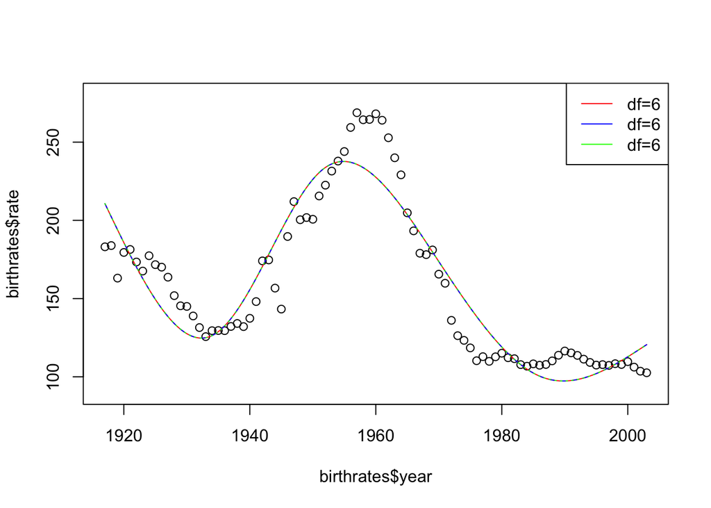

```r
#fit1, fit2 and fit3 produce the same results

# Alternatively, you can predict the spline fit on a fine grid, and then connect them

# plot(birthrates$year, birthrates$rate, ylim=c(90,280))
# year.grid = seq(from=min(birthrates$year), to=max(birthrates$year), length=200)
# ypred = predict(fit1, data.frame(year=year.grid))
# lines(year.grid, ypred, col="blue", lwd=2)

fit1=lm(rate~ns(year, knots=quantile(year, (1:4)/5)), data=birthrates);
fit2=lm(rate~ns(year, df=5), data=birthrates);
fit3=lm(rate~ns(year, df=6, intercept=TRUE), data=birthrates)

plot(birthrates$year, birthrates$rate, ylim=c(90,280))
lines(spline(birthrates$year, predict(fit1)), col="red", lty=1)
lines(spline(birthrates$year, predict(fit2)), col="blue", lty=2)
lines(spline(birthrates$year, predict(fit3)), col="green", lty=3)
legend("topright", lty=rep(1,2,3,), col=c("red", "blue", "green"), legend=c("df=6", "df=6", "df=6"))
```

```r
# Same results for all fits
```

### Try cubic splines with different degrees-of-freedoms

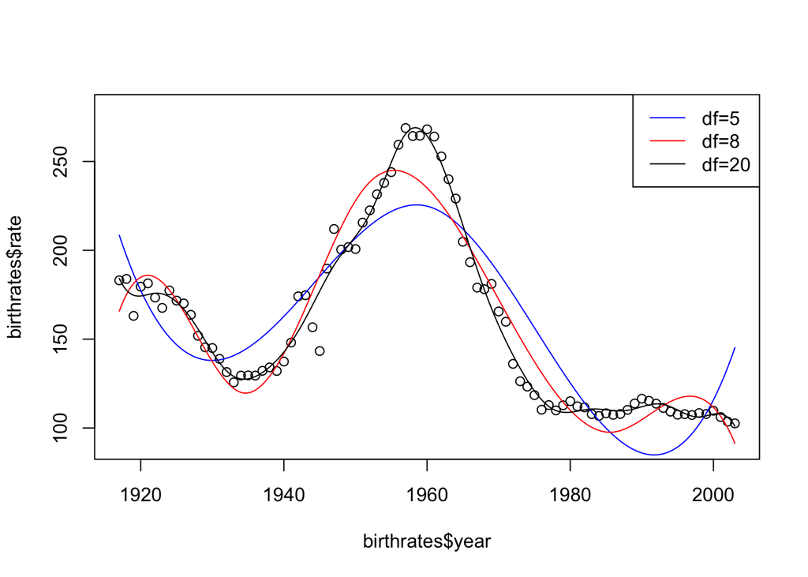

```r
plot(birthrates$year, birthrates$rate, ylim=c(90,280));
lines(spline(birthrates$year, predict(lm(rate~bs(year, df=4), data=birthrates))), col="blue");
lines(spline(birthrates$year, predict(lm(rate~bs(year, df=7), data=birthrates))), col="red");
lines(spline(birthrates$year, predict(lm(rate~bs(year, df=19), data=birthrates))), col="black");
legend("topright", lty=rep(1,3), col=c("blue", "red", "black"), legend=c("df=5", "df=8", "df=20"))
```

From the previous graph, it looks like something between 8 and 20 knots would be adequate. How can we choose the number of knots?

### Use 10-fold Cross-Validation (CV) to select df (or equivalently the number of knots)

The location of knots will affect the performance of a spline model. But selecting the location of knots is computationally too expensive. Instead, we always place knots equally at quantiles of x, and then select just the number of knots, or equivalently, the df. **Can we use F-test to select the number of knots?**

For each df, we use 10-fold CV to calculate the CV error. When doing 10-fold CV, each time, based on 90% of the data, we place the (df-4) knots at the corresponding quantiles and then fit a regression spline

First, we need to divide the data into K folds. You could use the following command, but when the sample size is relatively small, the foldsize could be very unbalanced.

```r
K=10
fold.id = sample(1:K, nrow(birthrates), replace=TRUE)
fold.id
```

```
##  [1]  1  5  5  5  6 10  9  8  4  1 10  4  7 10  7  6  3  3  6  3  2  1  8  8  6
## [26]  2  2  4  4  4  9  7  1  9  3  6  1  7  2  2  2  8  3  1  5  9 10  6  9  9
## [51]  9  6  4  9  1  1  7  7  6  3  1  3  6  2  9  2  4  2  3  4  4  8 10  7 10
## [76]  4  2  5  2  6  3  7  1 10  6  6  9
```

```r
table(fold.id)
```

```
## fold.id
##  1  2  3  4  5  6  7  8  9 10
## 10 11  9 10  5 12  8  5 10  7
```

Instead, we use the following command to divide the data into roughly equal size of folds.

```r
K=10
n = nrow(birthrates)
fold.size = c(rep(9, 7), rep(8, 3))
fold.size
```

```
##  [1] 9 9 9 9 9 9 9 8 8 8
```

```r
sum(fold.size)
```

```
## [1] 87
```

```r
fold.id = rep(0, n);
for(i in 1:(K-1)){
  tmp.id = sample((1:n)[fold.id == 0], fold.size[i], replace=FALSE)
  print(tmp.id)
  fold.id[tmp.id] = i
}
```

```
## [1] 51 14  1  7 59 30 81 66 47
## [1] 74 16 54 48 44 65 55 79 63
## [1] 72 42 19 31 49 52 25 11 39
## [1] 38 37 46 68 56 22 64 10 83
## [1]  3  4 34 43 75 40 53 45 29
## [1] 26 57  9 76 20 73 82 41 84
## [1] 58 85 86 78  8 70  5 60 80
## [1] 77 18 61 71 32  6 67 17
## [1] 12 50 15 87  2 21 33 35
```

```r
fold.id[fold.id==0] = K
fold.id
```

```
##  [1]  1  9  5  5  7  8  1  7  6  4  3  9 10  1  9  2  8  8  3  6  9  4 10 10  3
## [26]  6 10 10  5  1  3  8  9  5  9 10  4  4  3  5  6  3  5  2  5  4  1  2  3  9
## [51]  1  3  5  2  2  4  6  7  1  7  8 10  2  4  2  1  8  4 10  7  8  3  6  2  5
## [76]  6  8  7  2  7  1  6  4  6  7  7  9
```

```r
table(fold.id)
```

```
## fold.id
##  1  2  3  4  5  6  7  8  9 10
##  9  9  9  9  9  9  9  8  8  8
```

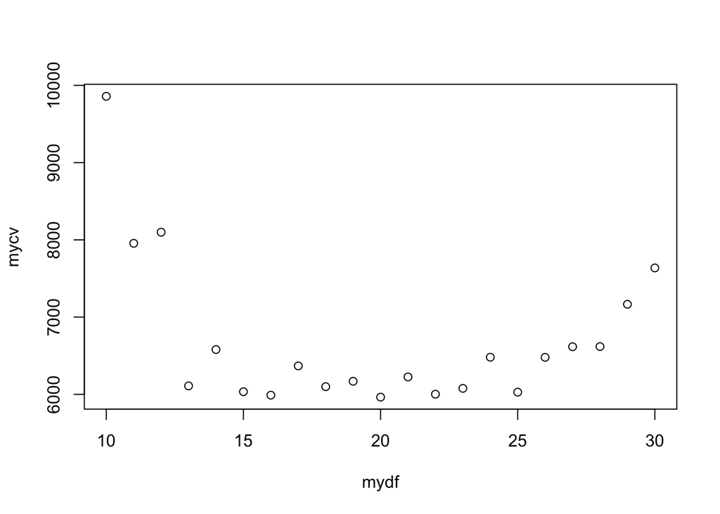

```r
mydf=10:30
mycv = rep(0, length(mydf))

for(i in 1:length(mydf)){
  m = mydf[i]-4;
  for(k in 1:K){
    id = which(fold.id == k);
    myknots = quantile(birthrates$year[-id], (1:m)/(m+1))
    myfit = lm(rate ~ bs(year, knots=myknots), data=birthrates[-id,])
    ypred = predict(myfit, newdata=birthrates[id,])
    mycv[i]=mycv[i] + sum((birthrates$rate[id] - ypred)^2)
  }
}
plot(mydf, mycv)
```

```r
mydf[which.min(mycv)]
```

```
## [1] 20
```

Re-run the 10-fold CV. The plot of mydf versus mycv may vary, but shouldn’t be too different.

```r
fold.id = rep(0, n);
for(i in 1:(K-1)){
  tmp.id = sample((1:n)[fold.id == 0], fold.size[i], replace=FALSE)
  print(tmp.id)
  fold.id[tmp.id] = i
  }
```

```
## [1] 53 18 52 80 66 16 59 23 21
## [1] 10 13 39 42 74 73 62 56 87
## [1] 78 20 40 69 57 44  2 81 41
## [1] 14 24 65 61 37 60 63  1 67
## [1] 85 11 83 33 54 45 49 32 58
## [1] 75  7 29 68 47 43 30 82 27
## [1] 38 48 36 22 15 51 86  6 64
## [1] 19 17 35 31 72 71  3  9
## [1]  8 84  5 70 28  4 76 55
```

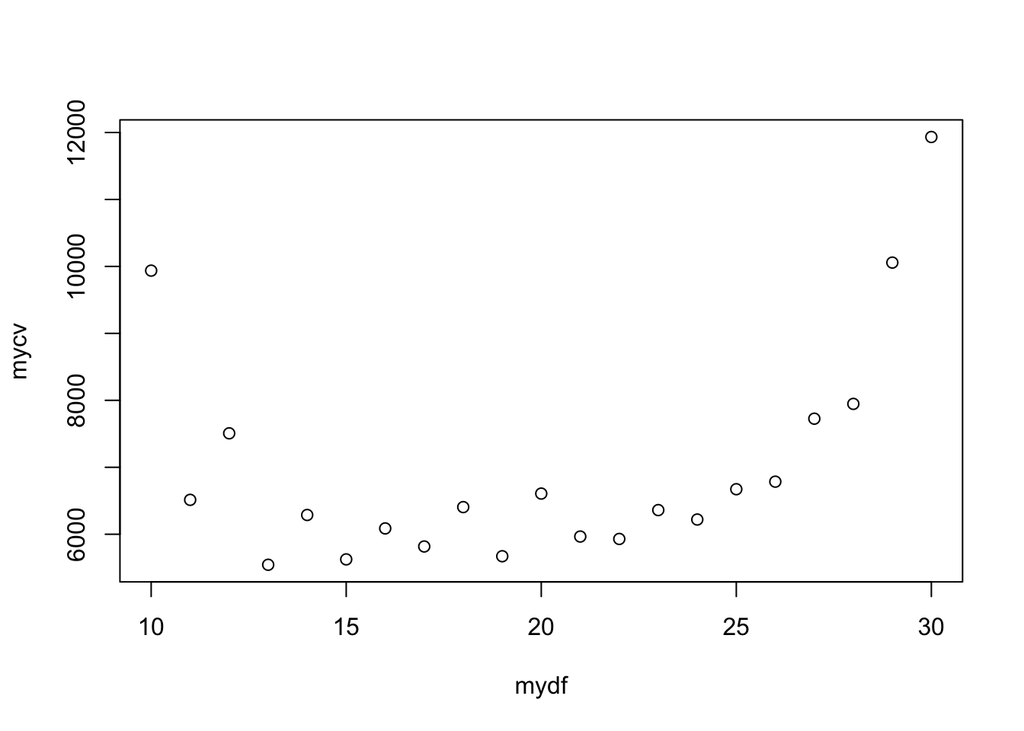

```r
fold.id[fold.id==0] = K
mycv = rep(0, length(mydf))

for(i in 1:length(mydf)){
  m = mydf[i]-4;
  myknots = quantile(birthrates$year, (1:m)/(m+1))
  for(k in 1:K){
    id = which(fold.id == k);
    myfit = lm(rate ~ bs(year, knots=myknots), data=birthrates[-id,])
    #myspline = interpSpline(year[-id], predict(myfit))
    ypred = predict(myfit, newdata=birthrates[id,])
    mycv[i]=mycv[i] + sum((birthrates$rate[id] - ypred)^2)
  }
}
plot(mydf, mycv)
```

```r
mydf[which.min(mycv)]
```

```
## [1] 13
```

Please note that we are splitting the data randomly in the time series, and this is not quite correct since the training set and test set will get scrambled. We need to do the data splitting sequentially. For more information on this topic please check:

https://www.analyticsvidhya.com/blog/2018/05/improve-model-performance-cross-validation-in-python-r/